# aflevering 7

2025-04-01

```r
firmaer<-read.csv("/Users/asgeraircool/rdata/Firmaer.csv")
head(firmaer)
```

```
##   Obs  omsaet  vaerdi sektor
## 1   1 9.08171 8.39344 detail
## 2   2 7.37838 6.75926 detail
## 3   3 7.71735 6.43455 detail
## 4   4 8.79710 7.38275 detail
## 5   5 9.74824 8.33759 detail
## 6   6 8.53307 8.14381 detail
```

```r
unique(firmaer$sektor)
```

```
## [1] "detail"   "energi"   "industri"
```

```r
detail<-subset(firmaer,subset=sektor=="detail")
energi<-subset(firmaer,subset=sektor=="energi")
industri<-subset(firmaer,subset=sektor=="industri")
```

##1

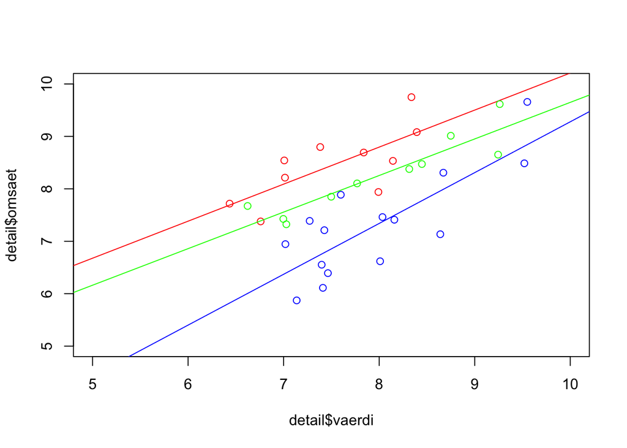

```r
lmd<-lm(omsaet~vaerdi,data=detail)
lme<-lm(omsaet~vaerdi,data=energi)
lmi<-lm(omsaet~vaerdi,data=industri)

plot(detail$vaerdi,detail$omsaet,col="red",xlim=c(5,10),ylim=c(5,10))
abline(lmd,col="red")
points(energi$vaerdi,energi$omsaet,col="blue")
abline(lme,col="blue")
points(industri$vaerdi,industri$omsaet,col="green")
abline(lmi,col="green")
```

det ser rimeligt ud at antage en lineær sammenhæng for at tjekke efter tegne vi residualplot

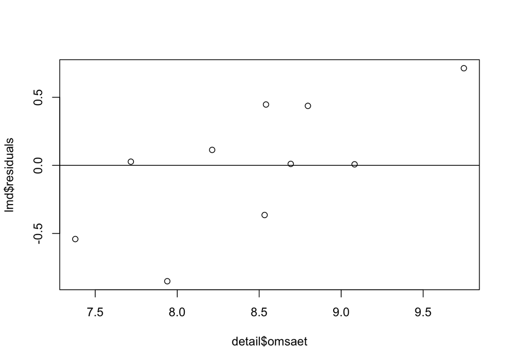

```r
plot(lmd$residuals~detail$omsaet)
abline(0,0)
```

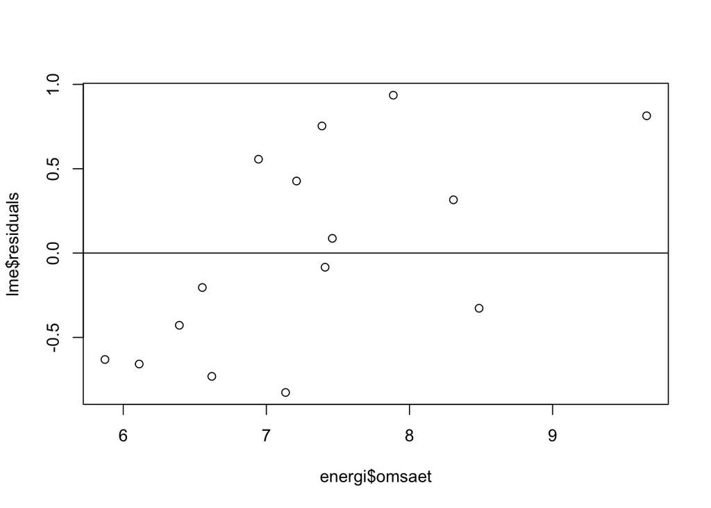

```r
plot(lme$residuals~energi$omsaet)
abline(0,0)
```

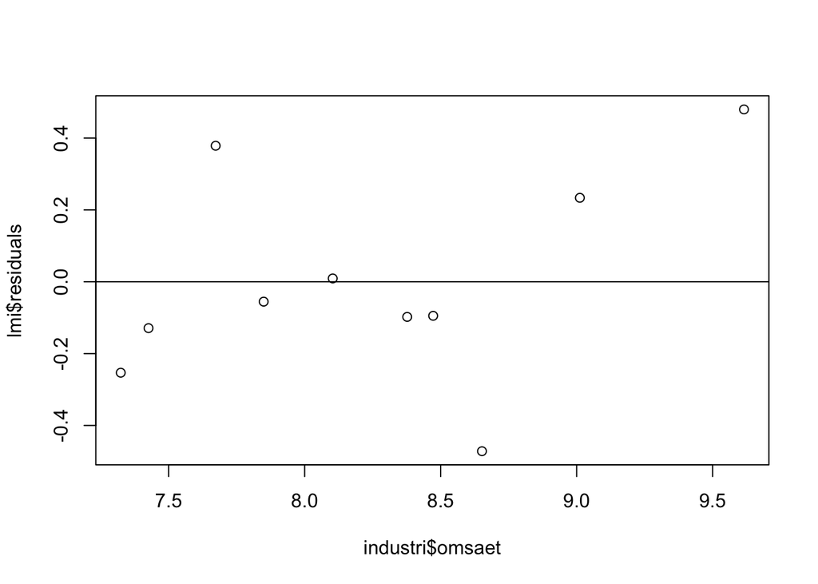

```r
plot(lmi$residuals~industri$omsaet)
abline(0,0)
```

igen ser residualerne rimelige ud uden systematisk afvigelse

altså starter vi i modellen $M_0: O_{i,k}\sim N(\alpha_i,\beta_i*V_{i,k}\,,\sigma_i^2)\quad for\,\,\, i\in \{detail,energi,industri\} \quad for \,\,k \in\{1,\dots,n_i\}$

##2 $H_0:\sigma_i^2 =\sigma_0^2\quad for \quad i \in\{detail,energi,industri\}$ vi kører en bartletts test for at tæste hypotesen

```r
bartlett.test(list(lmd,lme,lmi))
```

```
##
##  Bartlett test of homogeneity of variances
##
## data:  list(lmd, lme, lmi)
## Bartlett's K-squared = 4.0517, df = 2, p-value = 0.1319
```

p værdien er ikke kristisk så vi går videre med ens varians ##3 vi opskriver de rigtige neære modeller og kører anova for at se om det er rimligt at reducere modellen $M_1:=O_{i,k}\sim N(\alpha_i,\beta_i*V_{i,k}\,,\sigma_0^2)\quad for\,\,\, i\in \{detail,energi,industri\} \quad for \,\,k \in\{1,\dots,n_i\}$

$$M_2:O_{i,k}\sim
N(\alpha_i,\beta*V_{i,k}\,,\sigma_0^2)\quad for\,\,\, i\in
\{detail,energi,industri\} \quad for \,\,k \in\{1,\dots,n_i\}$$
vi tester hypotesen om at fi kan reducere fra m1 til m2 med anova

```r
lmm1<-lm(omsaet~sektor*vaerdi,data=firmaer)
lmm2<-lm(omsaet~sektor+vaerdi,data=firmaer)
anova(lmm2,lmm1)
```

```
## Analysis of Variance Table
##
## Model 1: omsaet ~ sektor + vaerdi
## Model 2: omsaet ~ sektor * vaerdi
##   Res.Df    RSS Df Sum of Sq      F Pr(>F)
## 1     31 8.2962
## 2     29 7.9097  2   0.38657 0.7087 0.5006
```

p værdien er ikke kritisk da kan det godt antages at hældningen er den samme ##4 vi kører summary på den lineære model

```r
summary(lmm2)
```

```
##
## Call:
## lm(formula = omsaet ~ sektor + vaerdi, data = firmaer)
##
## Residuals:
##      Min       1Q   Median       3Q      Max
## -0.90102 -0.36075 -0.01226  0.37861  1.06092
##
## Coefficients:
##                Estimate Std. Error t value Pr(>|t|)
## (Intercept)      2.3275     0.8486   2.743   0.0100 *
## sektorenergi    -1.5139     0.2163  -6.998 7.44e-08 ***
## sektorindustri  -0.5912     0.2370  -2.495   0.0181 *
## vaerdi           0.8150     0.1106   7.370 2.68e-08 ***
## ---
## Signif. codes:  0 '***' 0.001 '**' 0.01 '*' 0.05 '.' 0.1 ' ' 1
##
## Residual standard error: 0.5173 on 31 degrees of freedom
## Multiple R-squared:  0.7465, Adjusted R-squared:  0.7219
## F-statistic: 30.42 on 3 and 31 DF,  p-value: 2.299e-09
```

vi aflæser at p værdien for at $\beta=0$ som er meget kritisk altså kan vi ikke antage at hældningen er lig 0

##5 vi udregner konfidensintervallet

```r
df<-lmm2$df.residual
s<-sigma(lmm2)
upper<-sqrt((df*s^2)/qchisq(0.025,df))
lover<-sqrt((df*s^2)/qchisq(1-0.025,df))
lover
```

```
## [1] 0.4147375
```

```r
upper
```

```
## [1] 0.6877669
```

altså er 95% konfidensintervallet for $\sigma_0$ [0.4147375 ,0.6877669]

##6

vi aflæser fra confint

```r
confint(lmm2)
```

```
##                     2.5 %     97.5 %
## (Intercept)     0.5967555  4.0582560
## sektorenergi   -1.9551102 -1.0726982
## sektorindustri -1.0745116 -0.1079832
## vaerdi          0.5894214  1.0404821
```

da har vi at 95% konfidensintervalet for $\beta$ er [0.5894214, 1.0404821]